# World Population Trend and CO2 Emission

NIYIGENA Fiston 2025MBI

November 2026

# 1 Abstract

This project looks at how population size is related to carbon dioxide (CO₂) emissions using two datasets: World Population and CO₂ Emissions. It involves checking and cleaning the data, estimating population in 2030, creating graphs to show population and CO₂ trends, and examining relationships between the variables.

The population dataset contains 234 countries and territories, while the CO₂ dataset contains 215 country records. Not all countries could be matched between the two datasets because of differences in country names and missing data.

It is important to note that CO₂ emissions are measured per person (metric tons per capita), not as each country’s total emissions. Therefore, the results show relationships involving emissions per person rather than total CO₂ output.

# 2 1. Introduction

Population growth can increase the need for energy, transport, goods and other resources. These activities can contribute to CO₂ emissions. However, emissions also depend on how countries produce energy, their economic activities, technology and people’s lifestyles.

This project aims to study population trends and find out whether countries with larger populations also tend to have higher CO₂ emissions.

# 3 2. Methods and dataset

The population dataset includes country/territory, continent, population at selected years, area, density, growth rate and world population percentage. The CO₂ dataset contains annual values from 1990 to 2019 and identifies the indicator as CO₂ emissions (metric tons per capita).

The population data are merged with the CO₂ data using country names. The supplied CO₂ file has both `2019` and `2019.1`; this analysis uses `2019` and excludes the duplicate `2019.1` field.

## 3.1 Load and prepare the data

The following code loads both datasets, checks for duplicate records, and prepares the CO₂ dataset by identifying the 2019 column and removing any duplicate 2019 field.

```r
# Required packages
required <- c("tidyverse", "scales")

missing_packages <- required[
  !vapply(required, requireNamespace, logical(1), quietly = TRUE)
]

if (length(missing_packages) > 0) {
  install.packages(missing_packages)
}

library(tidyverse)
```

```r
library(ggplot2)
library(scales)
# 1. Load and prepare data

## Load population dataset

pop <- read_csv(
  "D:\\DOC\\COURSES\\BIG DATA ANALYTICS\\Rfor date science\\Min term exam\\world_population.csv",
  show_col_types = FALSE
) %>%
  distinct()

## Load CO2 dataset

co2_raw <- read_csv(
  "D:\\DOC\\COURSES\\BIG DATA ANALYTICS\\Rfor date science\\Min term exam\\CO2_emission.csv",
  show_col_types = FALSE
)
## Identify columns beginning with 2019

year2019_cols <- names(co2_raw)[
  stringr::str_detect(names(co2_raw), "^2019($|[.])")
]

## Check whether a 2019 column exists

if (length(year2019_cols) == 0) {
  stop("No 2019 column found. Check the CSV column names.")
}

## Rename the first 2019 column

names(co2_raw)[match(year2019_cols[1], names(co2_raw))] <- "2019"

## Remove duplicate 2019 columns

if (length(year2019_cols) > 1) {
  duplicate_idx <- match(year2019_cols[-1], names(co2_raw))
  co2_raw <- co2_raw[, -duplicate_idx, drop = FALSE]
}

## Final cleaned dataset

co2 <- as_tibble(co2_raw) %>%
  distinct()

## Create folder for project outputs

dir.create("project_output", showWarnings = FALSE)
```

# 4 3. Results and findings

## 4.1 3.1 Exploratory data analysis

This section checks the quality and structure of the datasets. It shows the number of rows and columns, column names, sample records, data types, duplicate records and missing values. A boxplot is also used to identify possible outliers in the numerical population data.

```r
# 2. Exploratory data analysis

## Display population dataset dimensions

cat("\nPOPULATION DATASET DIMENSIONS\n")
```

```
##
## POPULATION DATASET DIMENSIONS
```

```r
print(dim(pop))
```

```
## [1] 234  17
```

```r
## Display variable names

names(pop)
```

```
##  [1] "Rank"                        "CCA3"
##  [3] "Country/Territory"           "Capital"
##  [5] "Continent"                   "2022 Population"
##  [7] "2020 Population"             "2015 Population"
##  [9] "2010 Population"             "2000 Population"
## [11] "1990 Population"             "1980 Population"
## [13] "1970 Population"             "Area (km²)"
## [15] "Density (per km²)"           "Growth Rate"
## [17] "World Population Percentage"
```

```r
## Display the top 5 rows

head(pop, 5)
```

```
## # A tibble: 5 × 17
##    Rank CCA3  `Country/Territory` Capital          Continent `2022 Population`
##   <dbl> <chr> <chr>               <chr>            <chr>                 <dbl>
## 1    36 AFG   Afghanistan         Kabul            Asia               41128771
## 2   138 ALB   Albania             Tirana           Europe              2842321
## 3    34 DZA   Algeria             Algiers          Africa             44903225
## 4   213 ASM   American Samoa      Pago Pago        Oceania               44273
## 5   203 AND   Andorra             Andorra la Vella Europe                79824
## # ℹ 11 more variables: `2020 Population` <dbl>, `2015 Population` <dbl>,
## #   `2010 Population` <dbl>, `2000 Population` <dbl>, `1990 Population` <dbl>,
## #   `1980 Population` <dbl>, `1970 Population` <dbl>, `Area (km²)` <dbl>,
## #   `Density (per km²)` <dbl>, `Growth Rate` <dbl>,
## #   `World Population Percentage` <dbl>
```

```r
## Display the bottom 10 rows

tail(pop, 10)
```

```
## # A tibble: 10 × 17
##     Rank CCA3  `Country/Territory` Capital      Continent     `2022 Population`
##    <dbl> <chr> <chr>               <chr>        <chr>                     <dbl>
##  1    43 UZB   Uzbekistan          Tashkent     Asia                   34627652
##  2   181 VUT   Vanuatu             Port-Vila    Oceania                  326740
##  3   234 VAT   Vatican City        Vatican City Europe                      510
##  4    51 VEN   Venezuela           Caracas      South America          28301696
##  5    16 VNM   Vietnam             Hanoi        Asia                   98186856
##  6   226 WLF   Wallis and Futuna   Mata-Utu     Oceania                   11572
##  7   172 ESH   Western Sahara      El Aaiún     Africa                   575986
##  8    46 YEM   Yemen               Sanaa        Asia                   33696614
##  9    63 ZMB   Zambia              Lusaka       Africa                 20017675
## 10    74 ZWE   Zimbabwe            Harare       Africa                 16320537
## # ℹ 11 more variables: `2020 Population` <dbl>, `2015 Population` <dbl>,
## #   `2010 Population` <dbl>, `2000 Population` <dbl>, `1990 Population` <dbl>,
## #   `1980 Population` <dbl>, `1970 Population` <dbl>, `Area (km²)` <dbl>,
## #   `Density (per km²)` <dbl>, `Growth Rate` <dbl>,
## #   `World Population Percentage` <dbl>
```

```r
## Display data types

sapply(pop, class)
```

```
##                        Rank                        CCA3
##                   "numeric"                 "character"
##           Country/Territory                     Capital
##                 "character"                 "character"
##                   Continent             2022 Population
##                 "character"                   "numeric"
##             2020 Population             2015 Population
##                   "numeric"                   "numeric"
##             2010 Population             2000 Population
##                   "numeric"                   "numeric"
##             1990 Population             1980 Population
##                   "numeric"                   "numeric"
##             1970 Population                  Area (km²)
##                   "numeric"                   "numeric"
##           Density (per km²)                 Growth Rate
##                   "numeric"                   "numeric"
## World Population Percentage
##                   "numeric"
```

```r
## Check number of duplicate rows

cat(
  "Population duplicates remaining:",
  sum(duplicated(pop)), "\n"
)
```

```
## Population duplicates remaining: 0
```

```r
cat(
  "CO2 duplicates remaining:",
  sum(duplicated(co2)), "\n"
)
```

```
## CO2 duplicates remaining: 0
```

```r
## Calculate missing values in the population dataset

missing_pop <- data.frame(
  variable = names(pop),
  missing = sapply(pop, function(x) sum(is.na(x)))
)

## Calculate missing values in the CO2 dataset

missing_co2 <- data.frame(
  variable = names(co2),
  missing = sapply(co2, function(x) sum(is.na(x)))
)

## Save missing-value summaries

write_csv(
  missing_pop,
  "project_output/missing_population.csv"
)

write_csv(
  missing_co2,
  "project_output/missing_CO2.csv"
)

## Display missing-value summaries

print(missing_pop)
```

```
##                                                variable missing
## Rank                                               Rank       0
## CCA3                                               CCA3       0
## Country/Territory                     Country/Territory       0
## Capital                                         Capital       0
## Continent                                     Continent       0
## 2022 Population                         2022 Population       0
## 2020 Population                         2020 Population       0
## 2015 Population                         2015 Population       0
## 2010 Population                         2010 Population       0
## 2000 Population                         2000 Population       0
## 1990 Population                         1990 Population       0
## 1980 Population                         1980 Population       0
## 1970 Population                         1970 Population       0
## Area (km²)                                   Area (km²)       0
## Density (per km²)                     Density (per km²)       0
## Growth Rate                                 Growth Rate       0
## World Population Percentage World Population Percentage       0
```

```r
print(missing_co2)
```

```
##                      variable missing
## Country Name     Country Name       0
## country_code     country_code       0
## Region                 Region       0
## Indicator Name Indicator Name       0
## 1990                     1990      30
## 1991                     1991      29
## 1992                     1992      26
## 1993                     1993      26
## 1994                     1994      26
## 1995                     1995      25
## 1996                     1996      25
## 1997                     1997      25
## 1998                     1998      26
## 1999                     1999      26
```

[output cut: 20 more lines]

### 4.1.1 Separate boxplots for population variables

This section creates a separate boxplot for each numerical population variable.

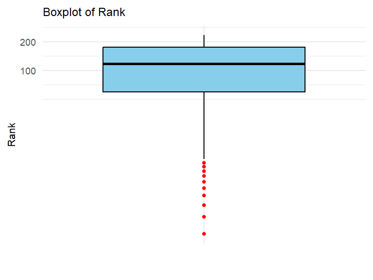

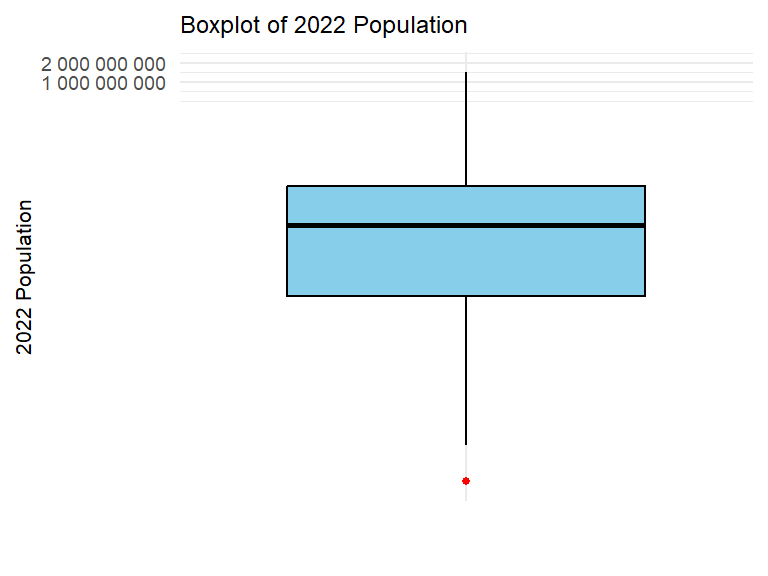

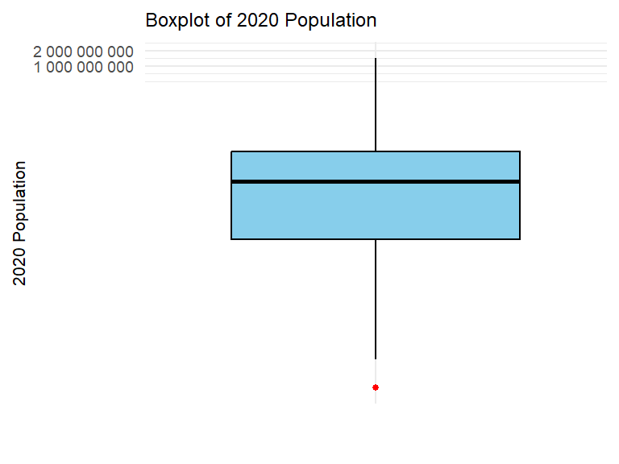

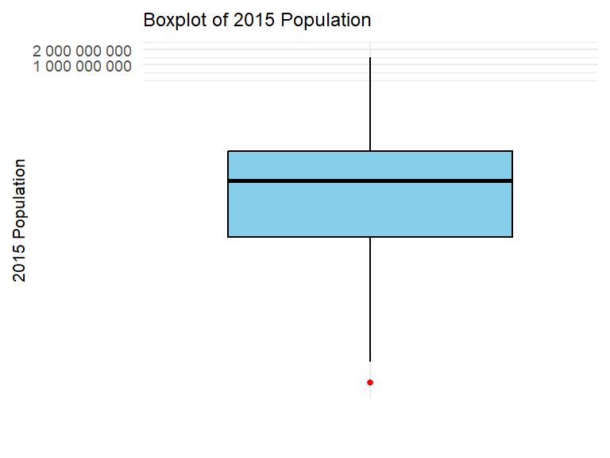

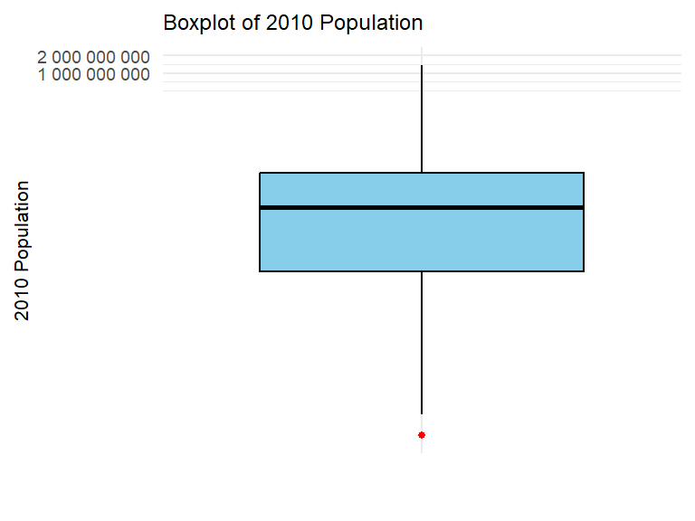

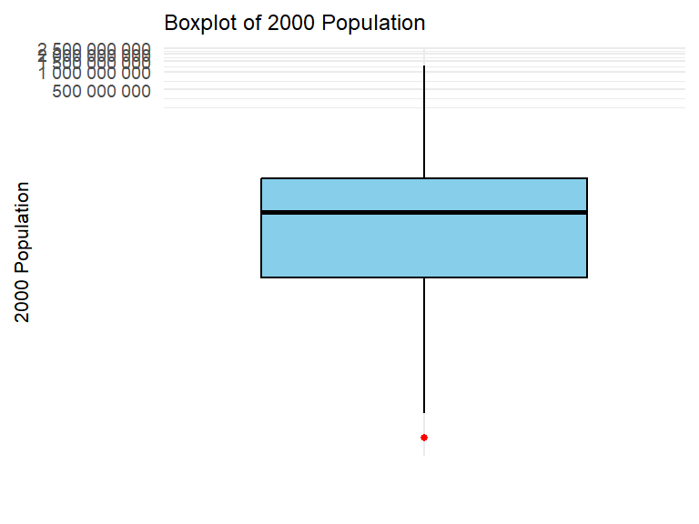

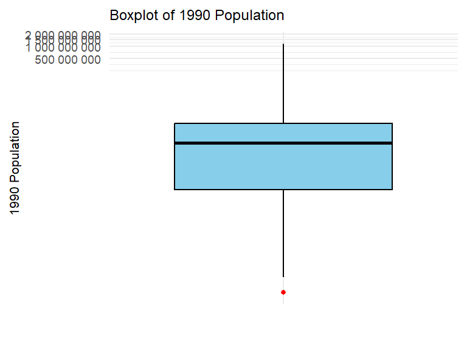

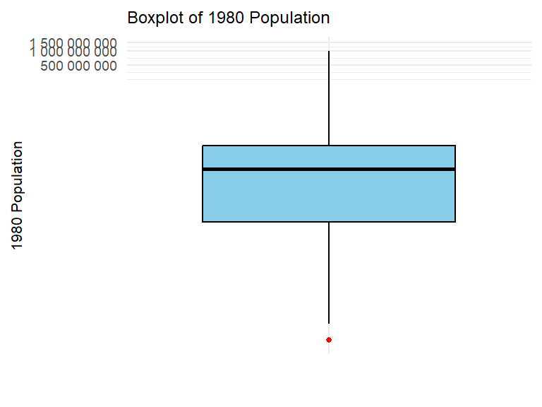

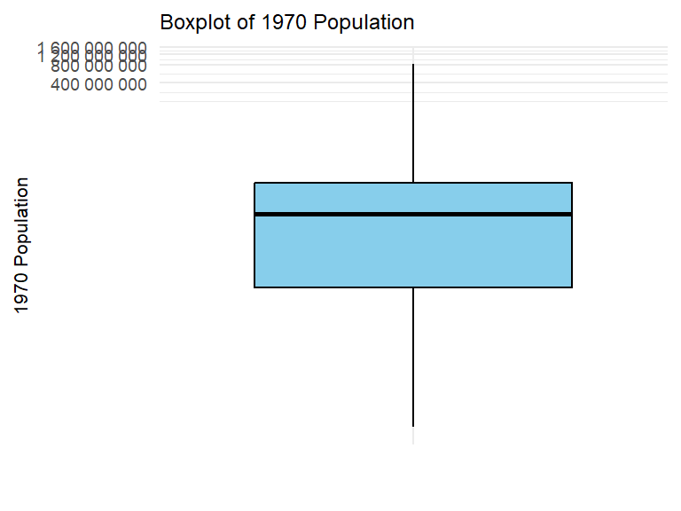

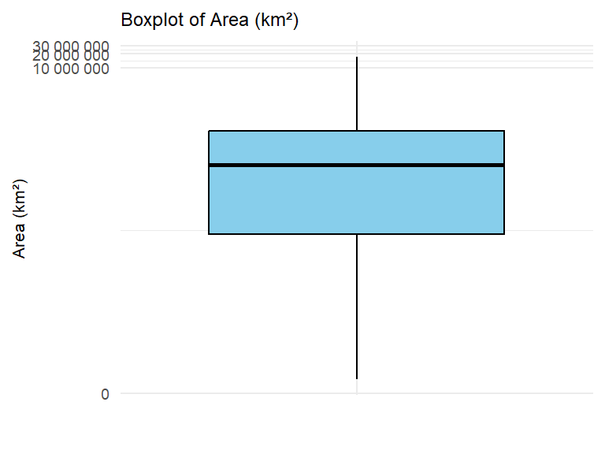

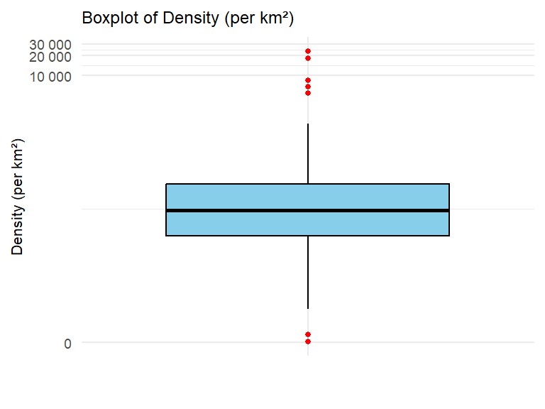

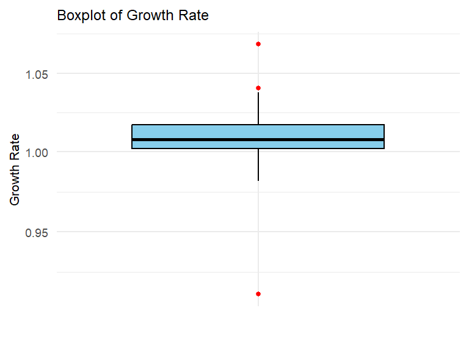

[1 more figures not shown]

```r
## Select numeric columns from the population dataset

numeric_pop <- pop %>%
  select(where(is.numeric))

## Create a separate boxplot for each variable

for (var in names(numeric_pop)) {

  p <- ggplot(
    numeric_pop,
    aes(x = "", y = .data[[var]])
  ) +
    geom_boxplot(
      fill = "skyblue",
      color = "black",
      outlier.color = "red",
      outlier.size = 1
    ) +
    scale_y_continuous(
      trans = "log1p",
      labels = scales::label_number()
    ) +
    labs(
      title = paste("Boxplot of", var),
      x = "",
      y = var
    ) +
    theme_minimal() +
    theme(
      plot.title = element_text(size = 9),
      axis.title = element_text(size = 8),
      axis.text = element_text(size = 7)
    )

  print(p)
}
```

The population dataset contains 234 rows and 17 columns, with no missing values or duplicate records. The CO₂ dataset contains 215 rows, but some country-year values are missing. These missing values are kept as `NA` instead of being changed to zero, because a missing value does not mean that a country had no CO₂ emissions.

Boxplots are used to identify possible outliers. Some countries naturally have much larger populations and land areas than others, so these values are not automatically removed. No missing population values are filled in because all the population data is complete.

### 4.1.2 Displaying the number of outliers

The following code calculates and displays the number of outliers in each numerical population variable.

```r
## Calculate the number of outliers

outlier_count <- function(x) {

  x <- na.omit(x)

  Q1 <- quantile(x, 0.25)
  Q3 <- quantile(x, 0.75)

  IQR_value <- IQR(x)

  lower_limit <- Q1 - 1.5 * IQR_value
  upper_limit <- Q3 + 1.5 * IQR_value

  sum(x < lower_limit | x > upper_limit)
}

## Apply the function to all numeric variables

outlier_summary <- data.frame(
  variable = names(numeric_pop),
  number_of_outliers = sapply(
    numeric_pop,
    outlier_count
  )
)

## Display the results

print(outlier_summary)
```

```
##                                                variable number_of_outliers
## Rank                                               Rank                  0
## 2022 Population                         2022 Population                 25
## 2020 Population                         2020 Population                 26
## 2015 Population                         2015 Population                 27
## 2010 Population                         2010 Population                 26
## 2000 Population                         2000 Population                 29
## 1990 Population                         1990 Population                 31
## 1980 Population                         1980 Population                 32
## 1970 Population                         1970 Population                 29
## Area (km²)                                   Area (km²)                 28
## Density (per km²)                     Density (per km²)                 22
## Growth Rate                                 Growth Rate                  3
## World Population Percentage World Population Percentage                 25
```

## 4.2 3.2 Predicting population in 2030

The project specifies $N_t=P e^{rt}$, where $P$ is 2022 population and $t=8$ years. The supplied `Growth Rate` values are annual growth factors around 1. Therefore, the annual rate is interpreted as `Growth Rate - 1`.

The projection assumes that the annual growth rate remains constant from 2022 to 2030. It is a mathematical estimate, not an official population forecast.

```r
# 3. Project 2030 population

## Calculate population growth rate and predict 2030 population

pop <- pop %>%
  mutate(
    r = `Growth Rate` - 1,
    `2030 Population` = `2022 Population` * exp(r * 8)
  )

## Arrange countries from highest to lowest population

projection <- pop %>%
  arrange(desc(`2030 Population`)) %>%
  select(
    `Country/Territory`,
    `2022 Population`,
    `Growth Rate`,
    `2030 Population`
  )

## Display the top 10 countries

head(projection, 10)
```

```
## # A tibble: 10 × 4
##    `Country/Territory` `2022 Population` `Growth Rate` `2030 Population`
##    <chr>                           <dbl>         <dbl>             <dbl>
##  1 India                      1417173173         1.01        1496402904.
##  2 China                      1425887337         1           1425887337
##  3 United States               338289857         1.00         348731782.
##  4 Indonesia                   275501339         1.01         289974355.
##  5 Pakistan                    235824862         1.02         274757645.
##  6 Nigeria                     218541212         1.02         265011868.
##  7 Brazil                      215313498         1.00         223384633.
##  8 Bangladesh                  171186372         1.01         186634630.
##  9 Ethiopia                    123379924         1.03         151542848.
## 10 Russia                      144713314         0.997        141621023.
```

## 4.3 3.3 Top ten countries and population trend

```r
# 4. Top ten countries by 2022 population

## Select the 10 most populous countries in 2022

top10 <- pop %>%
  slice_max(
    `2022 Population`,
    n = 10,
    with_ties = FALSE
  )

## Display the top 10 countries

print(top10)
```

```
## # A tibble: 10 × 19
##     Rank CCA3  `Country/Territory` Capital          Continent  `2022 Population`
##    <dbl> <chr> <chr>               <chr>            <chr>                  <dbl>
##  1     1 CHN   China               Beijing          Asia              1425887337
##  2     2 IND   India               New Delhi        Asia              1417173173
##  3     3 USA   United States       Washington, D.C. North Ame…         338289857
##  4     4 IDN   Indonesia           Jakarta          Asia               275501339
##  5     5 PAK   Pakistan            Islamabad        Asia               235824862
##  6     6 NGA   Nigeria             Abuja            Africa             218541212
##  7     7 BRA   Brazil              Brasilia         South Ame…         215313498
##  8     8 BGD   Bangladesh          Dhaka            Asia               171186372
##  9     9 RUS   Russia              Moscow           Europe             144713314
## 10    10 MEX   Mexico              Mexico City      North Ame…         127504125
## # ℹ 13 more variables: `2020 Population` <dbl>, `2015 Population` <dbl>,
## #   `2010 Population` <dbl>, `2000 Population` <dbl>, `1990 Population` <dbl>,
## #   `1980 Population` <dbl>, `1970 Population` <dbl>, `Area (km²)` <dbl>,
## #   `Density (per km²)` <dbl>, `Growth Rate` <dbl>,
## #   `World Population Percentage` <dbl>, r <dbl>, `2030 Population` <dbl>
```

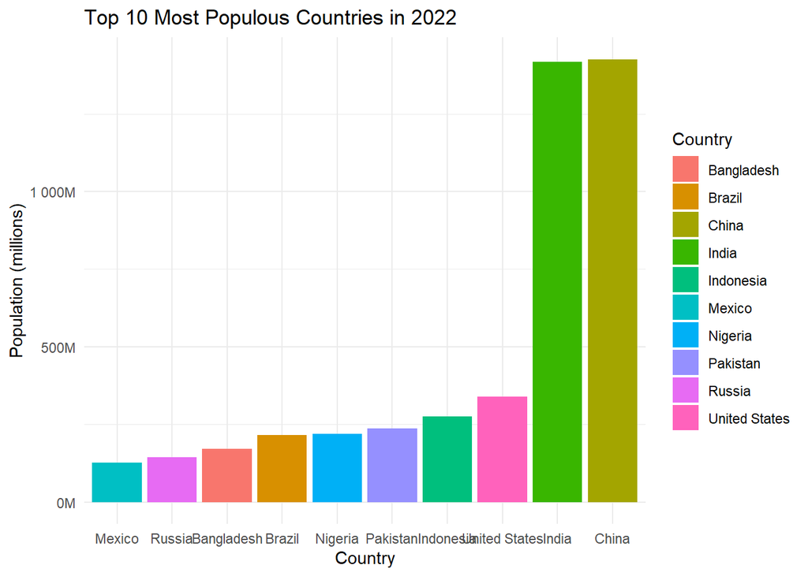

```r
## Create and display the bar chart

p_top <- ggplot(
  top10,
  aes(
    x = forcats::fct_reorder(
      `Country/Territory`,
      `2022 Population`,
      .desc = FALSE
    ),
    y = `2022 Population`,
    fill = `Country/Territory`
  )
) +
  geom_col() +
  scale_y_continuous(
    labels = label_number(
      scale = 1e-6,
      suffix = "M"
    )
  ) +
  labs(
    title = "Top 10 Most Populous Countries in 2022",
    x = "Country",
    y = "Population (millions)",
    fill = "Country"
  ) +
  theme_minimal() +
  theme(legend.position = "right")

print(p_top)
```

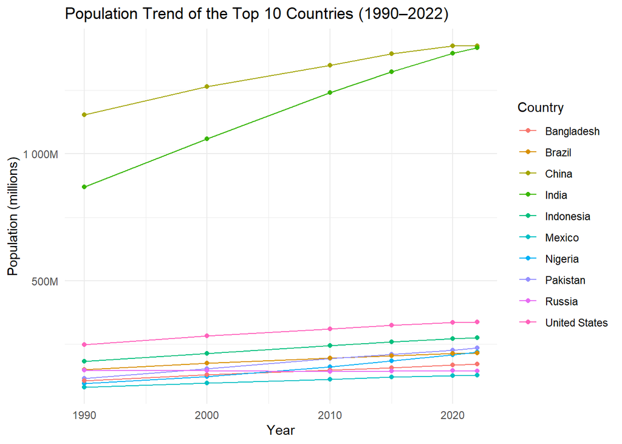

```r
## Select the population years

pop_years <- c(
  "1990 Population",
  "2000 Population",
  "2010 Population",
  "2015 Population",
  "2020 Population",
  "2022 Population"
)

## Prepare the data for the line graph

population_long <- top10 %>%
  select(
    `Country/Territory`,
    all_of(pop_years)
  ) %>%
  pivot_longer(
    cols = -`Country/Territory`,
    names_to = "Year",
    values_to = "Population"
  )

## Extract the year numbers

population_long$Year <- as.numeric(
  stringr::str_extract(
    population_long$Year,
    "\\d{4}"
  )
)

## Create the population trend graph

p_population_trend <- ggplot(
  population_long,
  aes(
    x = Year,
    y = Population,
    color = `Country/Territory`
  )
) +
  geom_line() +
  geom_point() +
  scale_y_continuous(
    labels = scales::label_number(
      scale = 1e-6,
      suffix = "M"
    )
  ) +
  labs(
    title = "Population Trend of the Top 10 Countries (1990–2022)",
    x = "Year",
    y = "Population (millions)",
    color = "Country"
  ) +
  theme_minimal()

## Display the graph

print(p_population_trend)
```

The population file provides selected benchmark years rather than annual observations. The line chart connects these available benchmark years; it should not be interpreted as annual measurements.

## 4.4 3.4 CO2 emission trend for the top ten

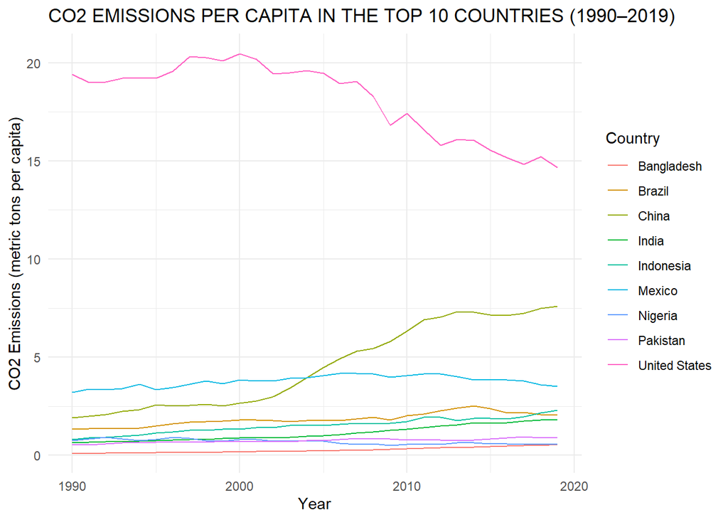

```r
# 5. CO2 trend for the same ten countries

## Select the CO2 years

years_CO2 <- as.character(1990:2019)

## Select the top 10 countries and their CO2 emissions

co2_top <- co2 %>%
  filter(
    `Country Name` %in% top10$`Country/Territory`
  ) %>%
  select(
    `Country Name`,
    all_of(years_CO2)
  ) %>%
  pivot_longer(
    cols = -`Country Name`,
    names_to = "Year",
    values_to = "Emission"
  )

## Convert years and emissions into numbers

co2_top$Year <- as.numeric(co2_top$Year)
co2_top$Emission <- as.numeric(co2_top$Emission)

## Create the CO2 emissions trend graph

p_co2_trend <- ggplot(
  co2_top,
  aes(
    x = Year,
    y = Emission,
    color = `Country Name`
  )
) +
  geom_line(na.rm = TRUE) +
  labs(
    title = "CO2 EMISSIONS PER CAPITA IN THE TOP 10 COUNTRIES (1990–2019)",
    x = "Year",
    y = "CO2 Emissions (metric tons per capita)",
    color = "Country"
  ) +
  theme_minimal()

## Display the graph

print(p_co2_trend)
```

Only available observations are plotted. The indicator is per capita, not total national CO₂ emissions.

## 4.5 3.5 Correlation analysis

This section looks at the relationships between land area, population density, growth rate and the percentage of the world’s population. Pearson correlation is used to measure how these variables are related. The results are also shown in a heatmap, making it easier to see whether the relationships are positive or negative and how strong they are.

```r
# 6. Correlation matrix and heatmap

## Select the variables to compare

correlation_data <- pop %>%
  select(
    `Area (km²)`,
    `Density (per km²)`,
    `Growth Rate`,
    `World Population Percentage`
  )

## Calculate the correlation between the variables

correlation_matrix <- cor(
  correlation_data,
  use = "complete.obs",
  method = "pearson"
)

## Display the correlation results

print(round(correlation_matrix, 2))
```

```
##                             Area (km²) Density (per km²) Growth Rate
## Area (km²)                        1.00             -0.06       -0.01
## Density (per km²)                -0.06              1.00       -0.07
## Growth Rate                      -0.01             -0.07        1.00
## World Population Percentage       0.45             -0.03       -0.02
##                             World Population Percentage
## Area (km²)                                         0.45
## Density (per km²)                                 -0.03
## Growth Rate                                       -0.02
## World Population Percentage                        1.00
```

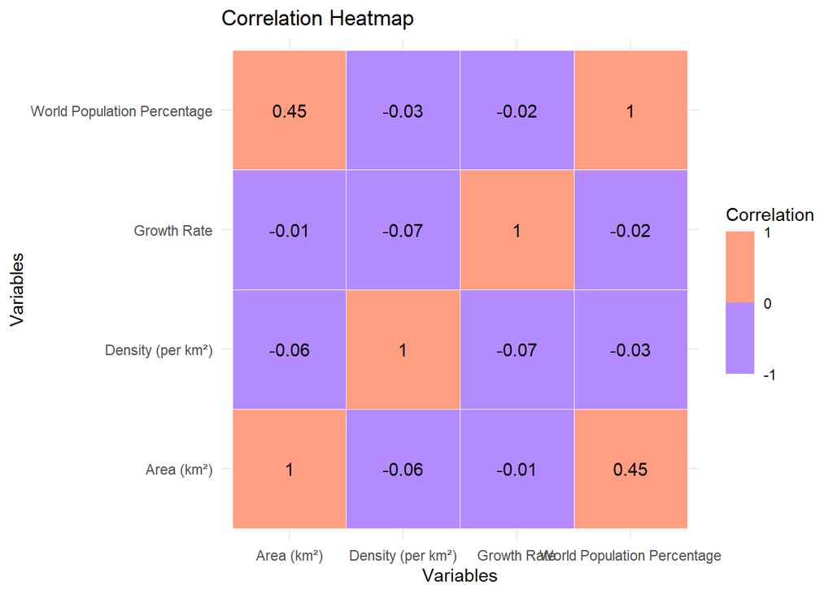

```r
## Prepare the results for the heatmap

correlation_long <- as.data.frame(
  as.table(correlation_matrix)
)

## Create the correlation heatmap

p_heatmap <- ggplot(
  correlation_long,
  aes(
    x = Var1,
    y = Var2,
    fill = Freq
  )
) +
  geom_tile(color = "white") +
  geom_text(
    aes(label = round(Freq, 2))
  ) +
  scale_fill_stepsn(
    colours = c("blue", "white", "red"),
    breaks = c(-1, 0, 1),
    limits = c(-1, 1)
  ) +
  labs(
    title = "Correlation Heatmap",
    x = "Variables",
    y = "Variables",
    fill = "Correlation"
  ) +
  theme_minimal()

## Display the heatmap

print(p_heatmap)
```

Pearson correlation measures linear association and does not establish causation.

## 4.6 3.6 Population and CO2 relationship

The population and CO₂ datasets are joined using country names. Countries without a reported 2019 CO₂ value or 2022 population value are excluded from this analysis. Pearson correlation and linear regression are used to examine the relationship between 2022 population and 2019 CO₂ emissions per capita. A scatter plot with a fitted regression line provides a visual summary.

```r
# 7. Merge population with CO2 and analyze 2019 relationship

## Combine population and CO2 data

merged <- pop %>%
  inner_join(
    co2 %>%
      select(
        `Country Name`,
        `2019`
      ),
    by = c(
      "Country/Territory" = "Country Name"
    )
  )

## Remove missing values

merged <- merged %>%
  filter(
    !is.na(`2019`),
    !is.na(`2022 Population`)
  )

## Display the number of matched countries

cat(
  "Number of matched countries:",
  nrow(merged),
  "\n"
)
```

```
## Number of matched countries: 168
```

```r
## Calculate the correlation between population and CO2 emissions

correlation <- cor.test(
  merged$`2022 Population`,
  merged$`2019`,
  method = "pearson"
)

print(correlation)
```

```
##
##  Pearson's product-moment correlation
##
## data:  merged$`2022 Population` and merged$`2019`
## t = 0.10527, df = 166, p-value = 0.9163
## alternative hypothesis: true correlation is not equal to 0
## 95 percent confidence interval:
##  -0.1434170  0.1593828
## sample estimates:
##         cor
## 0.008170163
```

```r
## Perform linear regression

regression <- lm(
  `2019` ~ `2022 Population`,
  data = merged
)

print(summary(regression))
```

```
##
## Call:
## lm(formula = `2019` ~ `2022 Population`, data = merged)
##
## Residuals:
##    Min     1Q Median     3Q    Max
## -4.065 -3.326 -1.209  1.474 28.369
##
## Coefficients:
##                    Estimate Std. Error t value Pr(>|t|)
## (Intercept)       4.105e+00  3.835e-01  10.703   <2e-16 ***
## `2022 Population` 2.449e-10  2.327e-09   0.105    0.916
## ---
## Signif. codes:  0 '***' 0.001 '**' 0.01 '*' 0.05 '.' 0.1 ' ' 1
##
## Residual standard error: 4.801 on 166 degrees of freedom
## Multiple R-squared:  6.675e-05,  Adjusted R-squared:  -0.005957
## F-statistic: 0.01108 on 1 and 166 DF,  p-value: 0.9163
```

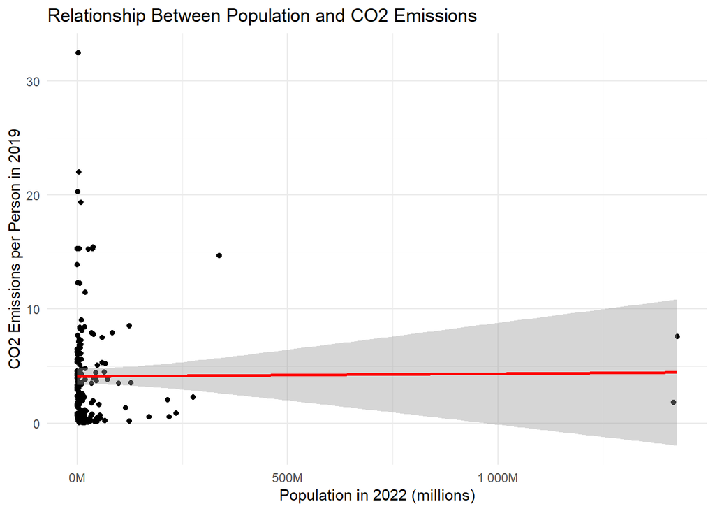

```r
## Create a scatter plot showing population and CO2 emissions

p_relationship <- ggplot(
  merged,
  aes(
    x = `2022 Population`,
    y = `2019`
  )
) +

  ## Show each country as a point

  geom_point() +

  ## Add a red line showing the general relationship

  geom_smooth(
    method = "lm",
    color = "red"
  ) +

  ## Display population values in millions

  scale_x_continuous(
    labels = scales::label_number(
      scale = 0.000001,
      suffix = "M"
    )
  ) +

  ## Add the graph title and axis labels

  labs(
    title = "Relationship Between Population and CO2 Emissions",
    x = "Population in 2022 (millions)",
    y = "CO2 Emissions per Person in 2019"
  ) +

  ## Give the graph a simple appearance

  theme_minimal()

## Display the graph

print(p_relationship)
```

The merged analysis uses only countries with a matching country name and a non-missing 2019 CO₂ value. Because the CO₂ variable is per capita, this analysis tests population size against per-capita emissions, not against total emissions.

## 4.7 3.7 Comparing CO2 emissions by continent

This section groups the matched countries by continent and compares the sum of their country-level 2019 CO₂ per-capita values. It also presents the comparison in a bar chart.

```r
# 8. Comparing CO2 emissions by continent

## Group countries according to their continents

continent_summary <- merged %>%
  group_by(Continent) %>%
  summarise(
    total_CO2 = sum(`2019`, na.rm = TRUE),
    countries_with_data = n(),
    .groups = "drop"
  ) %>%
  arrange(desc(total_CO2))

## Display the continent summary

print(continent_summary)
```

```
## # A tibble: 6 × 3
##   Continent     total_CO2 countries_with_data
##   <chr>             <dbl>               <int>
## 1 Asia              242.                   37
## 2 Europe            229.                   40
## 3 North America      79.6                  19
## 4 Africa             58.0                  48
## 5 Oceania            53.2                  13
## 6 South America      29.4                  11
```

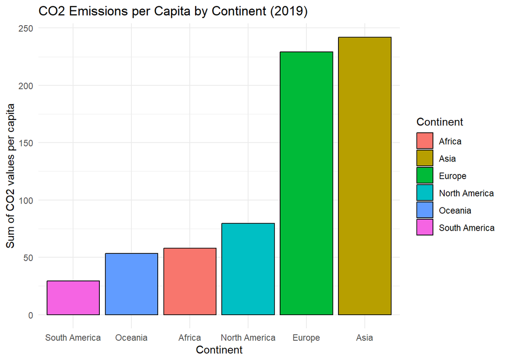

```r
## Create a bar chart comparing CO2 values by continent

p_continent <- ggplot(
  continent_summary,
  aes(
    x = reorder(Continent, total_CO2),
    y = total_CO2,
    fill = Continent
  )
) +
  geom_col(color = "black") +
  labs(
    title = "CO2 Emissions per Capita by Continent (2019)",
    x = "Continent",
    y = "Sum of CO2 values per capita",
    fill = "Continent"
  ) +
  theme_minimal() +
  theme(legend.position = "right")

## Display the graph

print(p_continent)
```

The population dataset provides the continent names, while the CO₂ dataset provides emissions per person for each country. The sum of these values is included for comparison in the assignment. However, adding per-person emission values does not give the total CO₂ emissions of a continent. For a more accurate comparison, we would need to calculate a population-weighted average or use a dataset showing total CO₂ emissions.

# 5 4. Discussion

Population size alone does not explain why countries have different levels of CO₂ emissions per person. Even countries with similar populations may have different energy sources, industries, income levels and transport systems, which can affect their emissions.

The analysis also has some limitations. Some CO₂ values are missing, and matching the two datasets depends on country names. In addition, the population projection assumes that the growth rate remains constant. Therefore, it should be treated as an estimate rather than an exact prediction.

# 6 5. Lessons learned and recommendations

This project shows how to work with data in R, including checking data quality, identifying missing values and duplicates, reshaping data, creating graphs, combining datasets, and performing correlation and regression analysis.

Future studies could improve the analysis by using standard country codes such as ISO3, collecting complete population data for each year, and using total CO₂ emissions to compare population size with total emissions. When comparing continents, it is better to use total emissions or population-weighted average emissions per person instead of simply adding per-person emission values.

# 7 6. Conclusion

The supplied datasets allow population trends and country-level per-capita CO₂ patterns to be explored. The 2030 projection is based on the stated exponential model and a constant growth-rate assumption. The merged statistical analysis should be interpreted cautiously because the CO₂ measure is per capita, some observations are missing, and population size is only one of many factors associated with emissions.